# Machine Learning Course Project: Human Activity Recognition

Nathaniel Reed

December 24, 2015

## Getting and Cleaning the Data

```r
training <- read.csv("pml-training.csv")
```

Subset by removing variables with missing data. In addition, to avoid over-fitting, we remove the timestamps and index variable “X”:

```r
toDrop <- c("kurtosis", "skewness", "avg_", "stddev", "var", "amplitude", "min", "max", "cvtd_timestamp", "num_window", "new_window", "user_name", "X", "raw_timestamp")
training <- subset(training, select = -grep(paste(toDrop, collapse="|"), names(training)))
```

## Exploratory Analysis: Feature plots

Density plots show the distributions of variables for each “classe” factor. There is a distinctive pattern per variable for each class of movement. Notice the arm and belt measurements below:

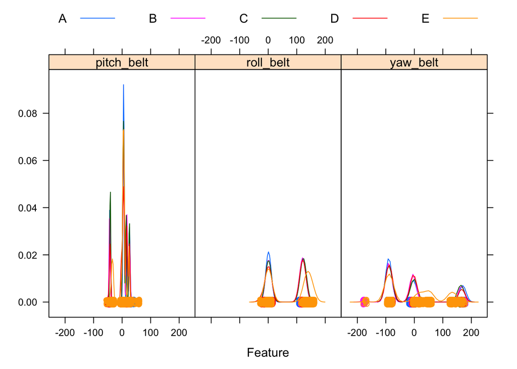

```r
featurePlot(x=training[,c("roll_belt", "pitch_belt", "yaw_belt")], y=training$classe, plot="density", auto.key=list(columns=5))
```

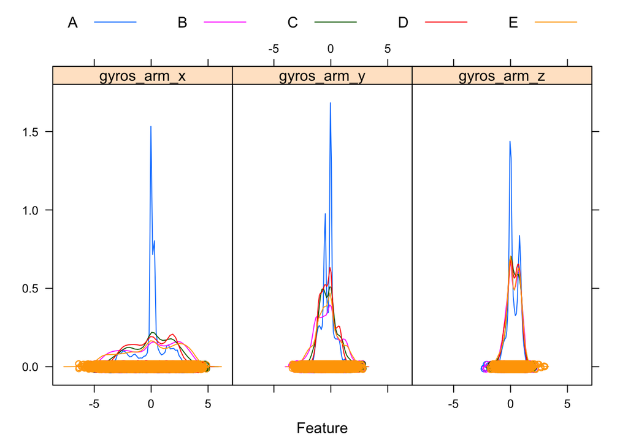

```r
featurePlot(x=training[,c("gyros_arm_x", "gyros_arm_y", "gyros_arm_z")], y=training$classe, plot="density", auto.key=list(columns=5))
```

The extents and averages of each variable can also tell us a lot about the movement. The minimum, maximum and mean measurements for the gyroscope x, y and z measurements are shown below. There seems to be a strong relationship between each variable and the type of movement:

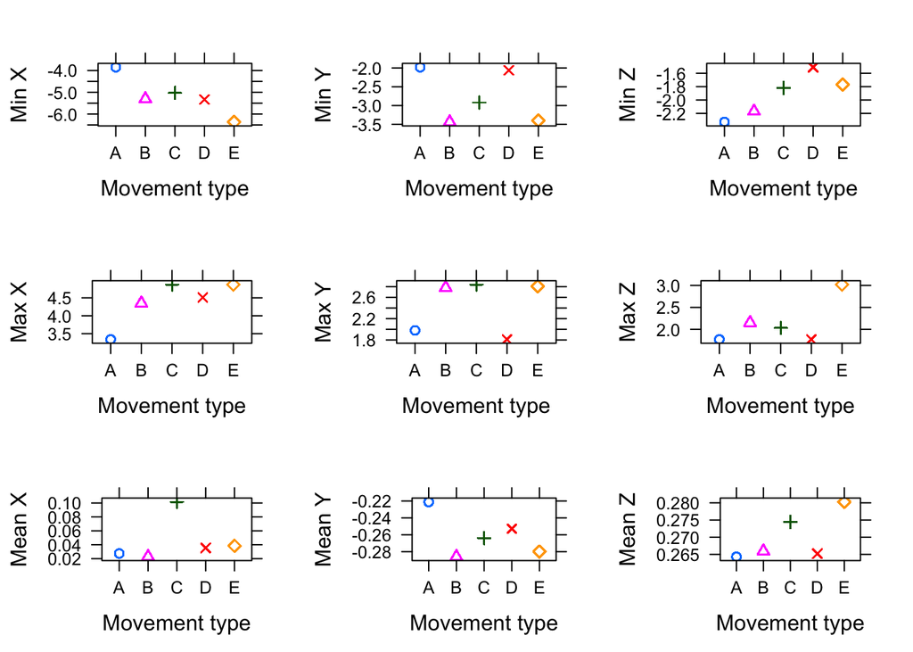

```r
by_classe <- group_by(training, classe) %>% mutate(min_gyros_arm_x = min(gyros_arm_x),
                                               min_gyros_arm_y = min(gyros_arm_y),
                                               min_gyros_arm_z = min(gyros_arm_z),
                                               max_gyros_arm_x = max(gyros_arm_x),
                                               max_gyros_arm_y = max(gyros_arm_y),
                                               max_gyros_arm_z = max(gyros_arm_z),
                                               mean_gyros_arm_x = mean(gyros_arm_x),
                                               mean_gyros_arm_y = mean(gyros_arm_y),
                                               mean_gyros_arm_z = mean(gyros_arm_z))
p1 <- xyplot(by_classe$min_gyros_arm_x ~ by_classe$classe, fill.color=colors, groups=by_classe$classe, pch=c(1,2,3,4,5), xlab = "Movement type", ylab="Min X")
p2 <- xyplot(by_classe$min_gyros_arm_y ~ by_classe$classe, fill.color=colors, groups=by_classe$classe, pch=c(1,2,3,4,5), xlab = "Movement type", ylab="Min Y")
p3 <- xyplot(by_classe$min_gyros_arm_z ~ by_classe$classe, fill.color=colors, groups=by_classe$classe, pch=c(1,2,3,4,5), xlab = "Movement type", ylab="Min Z")

p4 <- xyplot(by_classe$max_gyros_arm_x ~ by_classe$classe, fill.color=colors, groups=by_classe$classe, pch=c(1,2,3,4,5), xlab = "Movement type", ylab="Max X")
p5 <- xyplot(by_classe$max_gyros_arm_y ~ by_classe$classe, fill.color=colors, groups=by_classe$classe, pch=c(1,2,3,4,5), xlab = "Movement type", ylab="Max Y")
p6 <- xyplot(by_classe$max_gyros_arm_z ~ by_classe$classe, fill.color=colors, groups=by_classe$classe, pch=c(1,2,3,4,5), xlab = "Movement type", ylab="Max Z")

p7 <- xyplot(by_classe$mean_gyros_arm_x ~ by_classe$classe, fill.color=colors, groups=by_classe$classe, pch=c(1,2,3,4,5), xlab = "Movement type", ylab="Mean X")
p8 <- xyplot(by_classe$mean_gyros_arm_y ~ by_classe$classe, fill.color=colors, groups=by_classe$classe, pch=c(1,2,3,4,5), xlab = "Movement type", ylab="Mean Y")
p9 <- xyplot(by_classe$mean_gyros_arm_z ~ by_classe$classe, fill.color=colors, groups=by_classe$classe, pch=c(1,2,3,4,5), xlab = "Movement type", ylab="Mean Z")

grid.arrange(p1,p2,p3,p4,p5,p6,p7,p8,p9,ncol=3)
```

## Partition the Data

To speed up the building of our model and to validate the model we will use a portion of the data as a training set and the remainder for validation:

```r
InTrain<-createDataPartition(y=training$classe,p=0.3,list=FALSE)
training_subset<-training[InTrain,]
testing_subset<-training[-InTrain,]
```

## Model

For performance, we will register multiple cores with the multicore package, which will allow train() to build multiple trees in parallel. Your results may vary, depending on your hardware:

```r
library(doMC)
registerDoMC(5)
```

Next we build the model using random forests with with 5-fold cross-validation, setting allowParallel to enable train to take advantage of parallel processing:

```r
modFit <- train(classe~.,data=training_subset,method="rf",
                trControl=trainControl(method="cv",number=5),
                prox=TRUE,allowParallel=TRUE)
varImp(modFit)
```

```
## rf variable importance
##
##   only 20 most important variables shown (out of 52)
##
##                      Overall
## roll_belt            100.000
## pitch_forearm         63.846
## yaw_belt              49.119
## magnet_dumbbell_z     48.224
## magnet_dumbbell_y     46.892
## roll_forearm          44.133
## pitch_belt            41.225
## accel_dumbbell_y      25.672
## roll_dumbbell         22.333
## accel_forearm_x       19.694
## magnet_dumbbell_x     17.754
## magnet_belt_y         17.112
## magnet_belt_z         16.436
## accel_dumbbell_z      14.093
## magnet_forearm_z      13.772
## total_accel_dumbbell  13.756
## yaw_dumbbell          10.127
## accel_arm_x            9.858
## gyros_belt_z           9.671
## yaw_arm                9.664
```

## Cross-Validation

The resulting model is highly accurate, with an error rate of approximately 2%. We would like to see how accurate it is on the hold-out set of testing data, too:

```r
predictions <- predict(modFit, testing_subset)
confusionMatrix(predictions, testing_subset$classe)
```

```
## Confusion Matrix and Statistics
##
##           Reference
## Prediction    A    B    C    D    E
##          A 3891   49    0    0    0
##          B    4 2572   45   16    5
##          C    7   33 2335   51    5
##          D    3    3   15 2181   13
##          E    1    0    0    3 2501
##
## Overall Statistics
##
##                Accuracy : 0.9816
##                  95% CI : (0.9792, 0.9838)
##     No Information Rate : 0.2844
##     P-Value [Acc > NIR] : < 2.2e-16
##
##                   Kappa : 0.9767
##  Mcnemar's Test P-Value : 3.703e-16
##
## Statistics by Class:
##
##                      Class: A Class: B Class: C Class: D Class: E
## Sensitivity            0.9962   0.9680   0.9749   0.9689   0.9909
## Specificity            0.9950   0.9937   0.9915   0.9970   0.9996
## Pos Pred Value         0.9876   0.9735   0.9605   0.9847   0.9984
## Neg Pred Value         0.9985   0.9923   0.9947   0.9939   0.9980
## Prevalence             0.2844   0.1935   0.1744   0.1639   0.1838
## Detection Rate         0.2833   0.1873   0.1700   0.1588   0.1821
## Detection Prevalence   0.2869   0.1924   0.1770   0.1613   0.1824
## Balanced Accuracy      0.9956   0.9808   0.9832   0.9830   0.9953
```

We see that the model performs well on the testing data, too, with an accuracy of 98%.

## Analyzing Model Fit

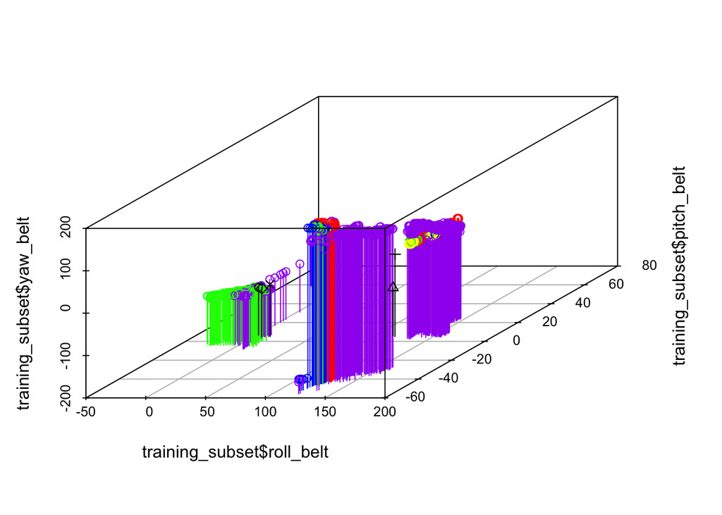

```r
classeP <- classCenter(training_subset[,c("roll_belt", "pitch_belt", "yaw_belt")], training_subset$classe, modFit$finalModel$proximity)
classeP <- as.data.frame(classeP); classeP$classe <- rownames(classeP)
colors <- c("red", "blue", "yellow", "green", "purple")
colors <- colors[as.numeric(training_subset$classe)]
s3d <- scatterplot3d(x=training_subset$roll_belt, y=training_subset$pitch_belt, z=training_subset$yaw_belt, type="h", color=colors)
s3d$points3d(x=classeP$roll_belt,
             y=classeP$pitch_belt,
             z=classeP$yaw_belt,
             type="h", data=classeP, pch=c(1,2,3,4,5), col="black")
```

## Source Code

The source code (.Rmd and .html) files for this page are available at http://github.com/natereed/coursera-machine-learning.